# Temperatura JP x CG

```r
climas = read_csv(here::here("data/clima_cg_jp-semanal.csv"),
                  col_types = "cTdddddd")
```

## Temperatura

### Onde é mais quente?

Para essa questão duas visualizações foram feitas com o objetivo de verificar como os dados estão distribuídos. Para o gráfico de boxplot temos o seguinte:

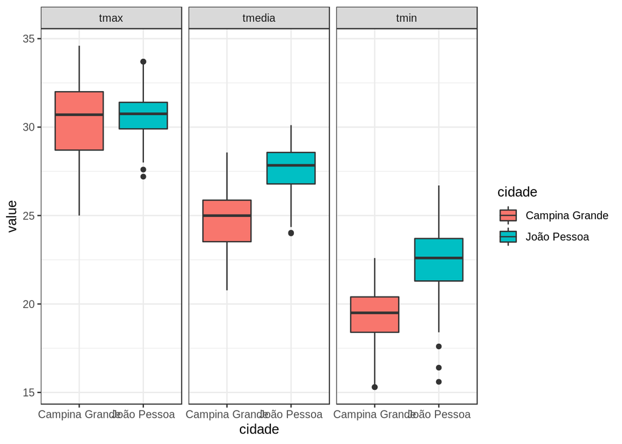

```r
temp <- melt(climas, measure.vars = c('tmax','tmedia','tmin'))

ggplot(temp, aes(x=cidade, y=value, fill=cidade)) +
    geom_boxplot() +
    facet_wrap(~variable)
```

Comparando as temperaturas máximas de cada cidade as medianas de João Pessoa e Campina Grande são praticamente as mesmas, porém ao comparar as temperaturas médias e mínimas as temperaturas medianas em João Pessoa são mais altas, mas ainda existe uma sobreposição muito grande.

Foi feita também uma visualização de linhas para verificar a mudança na temperatua ao longo do tempo nas duas cidades, porém para melhor visualizar os dados foram filtrados apenas os anos de 2016 em diante.

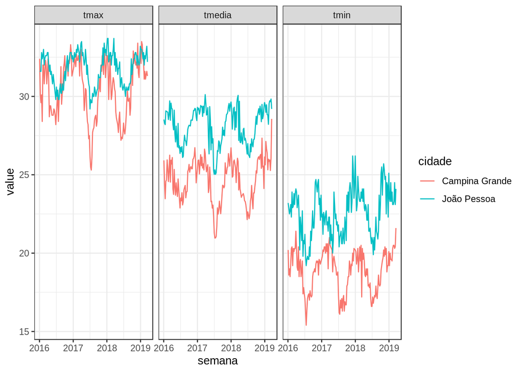

```r
temp <- temp[temp$ano >= 2016,]
ggplot(temp, aes(x=semana, y=value, colour=cidade)) +
    geom_line() +
    facet_wrap(~variable)
```

Com exceção das temperaturas máximas, as temperaturas médias e mínimas não se sobrepõe e as temperatuas de João Pessoa estão em um nível mais elevado quando comparadas com as de Campina Grande no mesmo período.

## Chuva

### A distribuição é diferente em meses específicos?

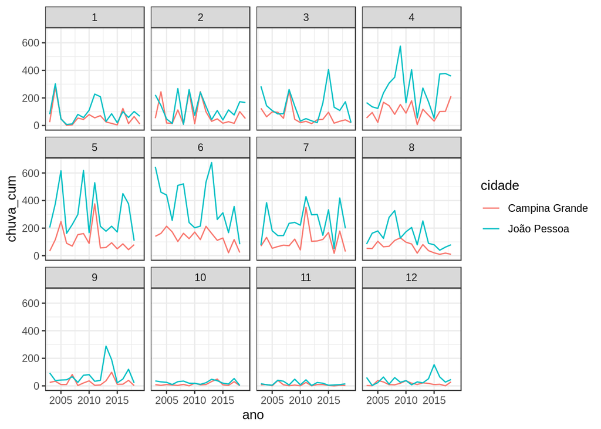

```r
chuvaMes <- climas %>% group_by(cidade, ano, mes) %>% summarise(chuva_cum = sum(chuva))
chuvaMes <- chuvaMes[chuvaMes$ano > 2002,]

ggplot(chuvaMes, aes(x=ano, y=chuva_cum, colour=cidade)) +
    geom_line() +
    facet_wrap(~factor(mes))
```

É possível perceber que o período mais chuvoso em ambas as cidades é entre os meses de Abril e Julho e os meses mesnos chuvosos são os meses de Outubro a Dezembro. Geralmente, em João Pessoa chove mais que em Campina Grande, com exceção de alguns meses em anos específicos como em fevereiro de 2004. A maior diferença é observada no mês de Junho que é o mês mais chuvoso em ambas as cidades.

### Existe relação entre a chuva e a temperatura de cada mês?

Para verificar essa relação, primeiro foram separados os dados de cada cidade e após isso, os foi feito um scaterplot entre a menor temperatura máxima de cada mês/ano e quanto choveu nesse mesmo período.

```r
chuvaTemp <- climas %>% group_by(cidade, ano, mes) %>% summarise(chuva_sum = sum(chuva), tmax = min(tmax))
chuvaTemp <- chuvaTemp[chuvaTemp$ano > 2001,]
```

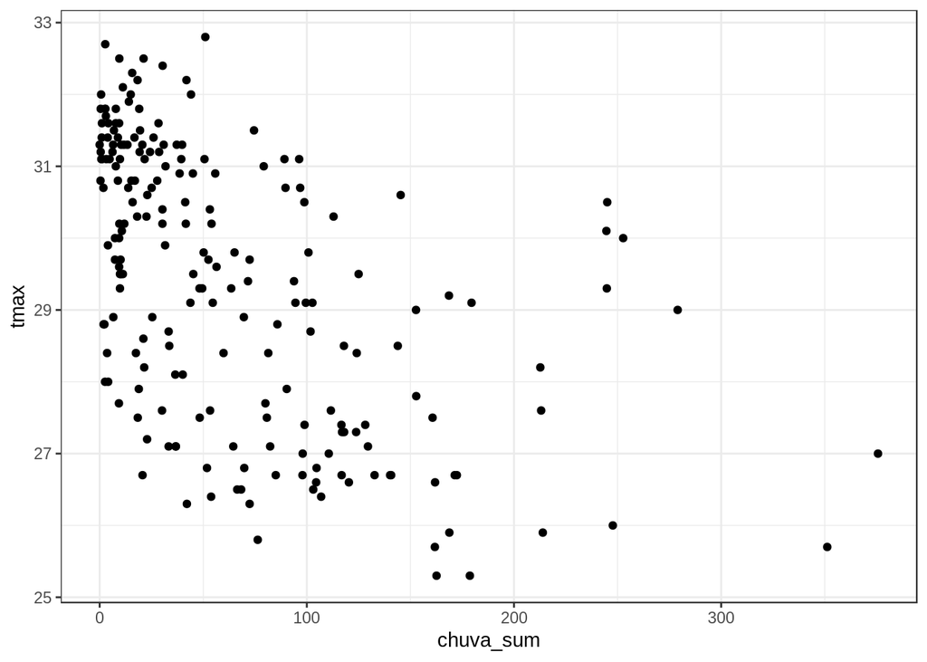

```r
chuvaTempCG <- chuvaTemp[chuvaTemp$cidade == "Campina Grande",]

ggplot(chuvaTempCG, aes(x=chuva_sum, y=tmax)) +
    geom_point()
```

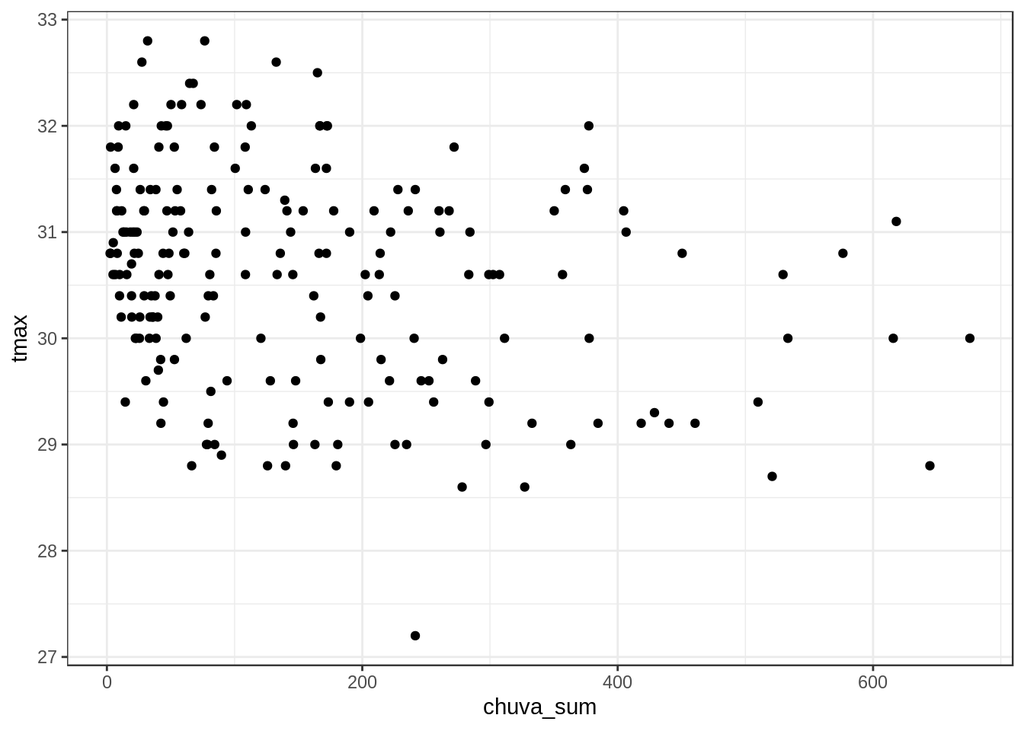

```r
chuvaTempJP <- chuvaTemp[chuvaTemp$cidade == "João Pessoa",]

ggplot(chuvaTempJP, aes(x=chuva_sum, y=tmax)) +
    geom_point()
```

Comparando os dois gráficos é possível perceber que em João Pessoa os dados estão mais dispersos e em Campina Grande existe uma concentração maior de pontos na parte superior esquerda, meses mais quentes e menos chuvosos, enquanto os pontos mais a direita, meses mais chuvosos, estão mais abaixo se comparados com os meses mais chuvosos de João Pessoa, indicando que a relação entre temperatura e chuva em Campina Grande é mais forte que em João Pessoa. Para verificar se isso acontece, foi realizado o calculo do coeficiente de correlação para cada município.

```r
cor(chuvaTempJP$chuva_sum, chuvaTempJP$tmax)
```

```
## [1] -0.2797338
```

```r
cor(chuvaTempCG$chuva_sum, chuvaTempCG$tmax)
```

```
## [1] -0.5286793
```

Em ambos os casos a correlação é negativa, indicando que quanto maior a temperatura menor a quantidade de chuva. Em João Pessoa essa correlação é mais próxima de 0, quando comparada com a de Campina Grande, indicando uma correlação mais fraca.